```python
import numpy as np
import matplotlib.pyplot as plt

def parseData():
    with open('C:\\Users\\saich\\Desktop\\UnsupervisedML\\Datasets\\AP_train.txt', 'r', encoding="utf8") as text:
        AuthorDetails=[]
        VenueDetails=[]
        PublicationDetails=[]
        lines=text.readlines()
        for line in lines:
            if '#index' in line[:8]:
                PublicationDetails.append(line[7:].rstrip())
            elif '#c' in line[:2]:
                VenueDetails.append(line[3:].rstrip())
            elif '#@' in line[:2]:
                for column in line[3:].rsplit(";"):
                    AuthorDetails.append(column.rstrip().lower())
    return PublicationDetails,AuthorDetails,VenueDetails
```

# After parsing the data for necessary variables we will perform general data mining and data visualizations across the dataset

```python
PublicationDetails,AuthorDetails,VenueDetails=parseData()
print("Count of Distinct Authors:" + str(len(set(AuthorDetails))))
print("Count of Distinct Venues:" + str(len(set(VenueDetails))-1))
print("Count of Distinct Publications:" + str(len(set(PublicationDetails))))
```

```
Count of Distinct Authors:1465859
Count of Distinct Venues:255685
Count of Distinct Publications:1976815
```

The below code obtains citations per publication which is stored in publiNCitations

```python
publiNCitations = {}
with open('C:\\Users\\saich\\Desktop\\UnsupervisedML\\Datasets\\AP_train.txt', 'r', encoding="utf8") as text :
    lines=text.readlines()
    for line in lines:
        if '#%' in line:
            if publiNCitations.get(line[3:].rstrip()) == None:
                publiNCitations[line[3:].rstrip()] = 1
            else:
                publiNCitations[line[3:].rstrip()] += 1
```

The below code obtains references per publication which is stored in publiNReferences

```python
publiNReferences = {}
with open('C:\\Users\\saich\\Desktop\\UnsupervisedML\\Datasets\\AP_train.txt', 'r', encoding="utf8") as text :
    lines=text.readlines()
    for line in lines:
        if '#index' in line:
            pub_id = line[7:].rstrip()
        elif '#%' in line:
            if publiNReferences.get(pub_id) == None:
                publiNReferences[pub_id] = 1
            else:
                publiNReferences[pub_id] += 1
```

The below code obtains citations per venue which is stored in venueNCitations

```python
venueNCitations = {}
with open('C:\\Users\\saich\\Desktop\\UnsupervisedML\\Datasets\\AP_train.txt', 'r', encoding="utf8") as text :
    lines=text.readlines()
    for line in lines:
        if '#c' in line:
             venue_id = line[3:].rstrip()
        elif '#%' in line:
            if venueNCitations.get(venue_id) == None:
                venueNCitations[venue_id] = 1
            else:
                venueNCitations[venue_id] += 1
```

```python
print("Total Citations :" , sum(publiNCitations.values()))
```

[output not shown]

# 1.b.

```python
MatchedValues = [s for s in VenueDetails if "Principles and Practice of Knowledge Discovery in Databases" in s]
```

```python
set(MatchedValues)
```

```
{'Knowledge Discovery in Databases: PKDD 2005: 9th European Conference on Principles and Practice of Knowledge Discovery in Databases, Porto, Portugal, October ... / Lecture Notes in Artificial Intelligence)',
 'Knowledge Discovery in Databases: PKDD 2006: 10th European Conference on Principles and Practice of Knowledge Discovery in Databases, Berlin, Germany, September ... (Lecture Notes in Computer Science)',
 "PKDD '04 Proceedings of the 8th European Conference on Principles and Practice of Knowledge Discovery in Databases",
 'PKDD 2007 Proceedings of the 11th European conference on Principles and Practice of Knowledge Discovery in Databases',
 "PKDD'05 Proceedings of the 9th European conference on Principles and Practice of Knowledge Discovery in Databases"}
```

All the above publications are of the same journal but of different year hence they do not count as separate, but due to the year value in the string we get them as separate items.

# 1.c.

```python
from collections import Counter
authorCounts = Counter(AuthorDetails)
```

```python
authorCountsDict = dict(authorCounts)
authorCountsDictKeys = list(authorCountsDict.keys())
authorCountsDictValues = list(authorCountsDict.values())
```

```python
authorCountsDictValues.pop(1)
```

```
42176
```

```python
authorCountsDictValues
```

[output not shown]

[output cut: 946 more lines]

[output not shown]

```python
plt.hist(authorCountsDictValues,bins = 20,log=True)
```

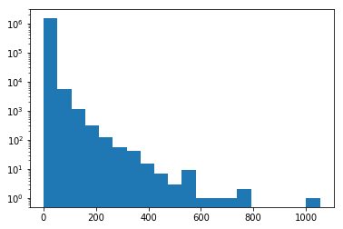

```python
plt.show()
```

# 1.d

```python
meanOfAuthors = np.mean(authorCountsDictValues)
standardDeviationOfAuthors = np.std(authorCountsDictValues)
firstQuartile = np.percentile(authorCountsDictValues, 25, axis=0)
median = np.percentile(authorCountsDictValues, 50, axis=0)
thirdQuartile = np.percentile(authorCountsDictValues, 75, axis=0)
minValue = min(authorCountsDictValues)
maxValue = max(authorCountsDictValues)

meanOfAuthors
```

```
3.3206981849537951
```

```python
standardDeviationOfAuthors
```

```
8.9128853807227202
```

```python
firstQuartile
```

```
1.0
```

```python
median
```

```
1.0
```

```python
maxValue
```

```
1054
```

```python
minValue
```

```
1
```

```python
thirdQuartile
```

```
2.0
```

median value is 1.0 whereas mean is 3.32, hence we can say from standard deviation and Q3 that the magnitudes of points increases very rapidly as the points move right.

# 1.e.

```python
VenueDetails
venueCleaned = VenueDetails
from collections import Counter
venueCleanedCounts = Counter(venueCleaned)
```

```python
venueCleanedCountsDict = dict(venueCleanedCounts)
venueCleanedCountsDictKeys = list(venueCleanedCountsDict.keys())
venueCleanedCountsDictValues = list(venueCleanedCountsDict.values())
```

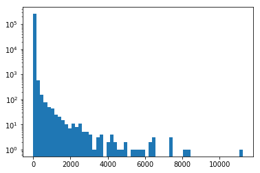

```python
plt.hist(venueCleanedCountsDictValues,bins = 60,log=True)
plt.show()
```

```python
meanOfVenues = np.mean(venueCleanedCountsDictValues)
standardDeviationOfVenues = np.std(venueCleanedCountsDictValues)
firstQuartile = np.percentile(venueCleanedCountsDictValues, 25, axis=0)
median = np.percentile(venueCleanedCountsDictValues, 50, axis=0)
thirdQuartile = np.percentile(venueCleanedCountsDictValues, 75, axis=0)
minValue = min(venueCleanedCountsDictValues)
maxValue = max(venueCleanedCountsDictValues)

meanOfVenues
```

```
7.7314166594964133
```

```python
standardDeviationOfVenues
```

```
83.381056103575318
```

```python
firstQuartile
```

```
1.0
```

```python
median
```

```
1.0
```

```python
thirdQuartile
```

```
1.0
```

```python
minValue
```

```
1
```

```python
maxValue
```

```
11227
```

```python
max(venueCleanedCountsDict, key=venueCleanedCountsDict.get)
```

```
'IEEE Transactions on Information Theory'
```

# 1.F.

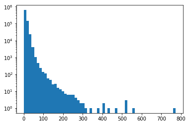

```python
referencesValues = list(publiNReferences.values())
referencesKeys=list(publiNReferences.keys())


plt.hist(referencesValues,bins = 60,log=True)
plt.show()
```

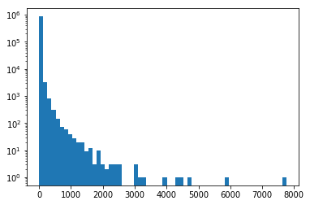

```python
citationValues = list(publiNCitations.values())
citationKeys=list(publiNCitations.keys())


plt.hist(citationValues,bins = 60,log=True)
plt.show()
```

```python
max(publiNCitations,key = publiNCitations.get)
```

```
'408396'
```

```python
max(publiNReferences,key = publiNReferences.get)
```

```
'719353'
```

# 1.G.

```python
for i in venueCleanedCountsDictKeys:
    if venueNCitations.get(str(i)) == None:
        venueNCitations[str(i)] = 1
```

```python
impactPerVenue = {}
for i in venueCleanedCountsDictKeys:
    impactPerVenue[str(i)] = (venueNCitations.get(str(i)))/venueCleanedCountsDict.get(str(i))
```

```python
venueCleanedCountsDictKeys
```

[output not shown]

[output cut: 946 more lines]

[output not shown]

```python
impactPerVenueList = list(impactPerVenue.values())
```

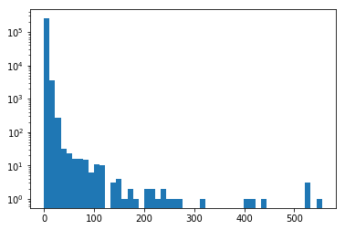

```python
plt.hist(impactPerVenueList,bins = 50,log=True)
plt.show()
```

```python
import operator
sorted_x = sorted(impactPerVenue.items(), key=operator.itemgetter(1),reverse=True)
```

```python
sorted_x
```

```
[('System-on-Chip Test Architectures: Nanometer Design for Testability',
  555.0),
 ('Human-centered visualization environments', 527.0),
 ('Algorithms for memory hierarchies: advanced lectures', 524.0),
 ('Reconfigurable Computing: The Theory and Practice of FPGA-Based Computation',
  523.0),
 ('Algorithm engineering: bridging the gap between algorithm theory and practice',
  435.0),
 ('Visualization in Medicine: Theory, Algorithms, and Applications', 412.0),
 ('Agent-oriented programming: from prolog to guarded definite clauses',
  408.0),
 ('No Code Required: Giving Users Tools to Transform the Web', 311.0),
 ('Networked Graphics: Building Networked Games and Virtual Environments',
  273.0),
 ('HCI Beyond the GUI: Design for Haptic, Speech, Olfactory, and Other Nontraditional Interfaces',
  264.0),
 ('Information Assurance: Dependability and Security in Networked Systems',
  245.0),
 ('Building Intelligent Interactive Tutors: Student-centered strategies for revolutionizing e-learning',
  239.0),
 ('On-Chip Communication Architectures: System on Chip Interconnect', 238.0),
 ('Algorithms for sensor and ad hoc networks: advanced lectures', 225.0),
 ('Models and tools for managing development processes', 212.0),
 ('P2P Networking and Applications', 211.0),
 ('Digital Modeling of Material Appearance', 202.0),
 ('Testing techniques in software engineering', 202.0),
 ('Processor Description Languages', 184.0),
 ("Physical Database Design: the database professional's guide to exploiting indexes, views, storage, and more",
  170.0),
 ('Visual affect recognition', 169.0),
 ('Text Entry Systems: Mobility, Accessibility, Universality', 163.0),
 ('Keeping Found Things Found: The Study and Practice of Personal Information Management: The Study and Practice of Personal Information Management',
  153.0),
 ('High Dynamic Range Imaging: Acquisition, Display, and Image-Based Lighting (The Morgan Kaufmann Series in Computer Graphics)',
  146.0),
 ('Optimal interprocedural program optimization: a new framework and its application',
  146.0),
 ('Mobile Technology for Children: Designing for Interaction and Learning',
  145.0),
 ('Abstract compositional analysis of iterated relations: a structural approach to complex state transition systems',
```

[output cut: 1677 more lines]

```
  17.541666666666668),
 ("ISCA '96 Proceedings of the 23rd annual international symposium on Computer architecture",
  17.535714285714285),
 ("SAS'12 Proceedings of the 19th international conference on Static Analysis",
  17.533333333333335),
 ('ASPLOS VI Proceedings of the sixth international conference on Architectural support for programming languages and operating systems',
  17.517241379310345),
 ("EGSR'10 Proceedings of the 21st Eurographics conference on Rendering",
  17.517241379310345),
 ('ACM SIGAPP Applied Computing Review - Special issue on coodination languages and models',
  17.5),
 ('Machine Learning - Special issue on natural language learning', 17.5),
 ("COMPOS'97 Revised Lectures from the International Symposium on Compositionality: The Significant Difference",
  17.5),
 ...]
```

Hence, maximum impact value is 555.0

```python
sorted(venueNCitations.items(), key=operator.itemgetter(1),reverse=True)
```

```
[('Expert Systems with Applications: An International Journal', 64583),
 ('Theoretical Computer Science', 46266),
 ('Information Sciences: an International Journal', 44534),
 ('IEEE Transactions on Computers', 40724),
 ('Pattern Recognition', 39724),
 ('Computer Communications', 38533),
 ('Journal of Computational Physics', 38242),
 ('Proceedings of the SIGCHI Conference on Human Factors in Computing Systems',
  31163),
 ('IEEE Transactions on Pattern Analysis and Machine Intelligence', 29318),
 ('Electronic Notes in Theoretical Computer Science (ENTCS)', 29139),
 ('Neurocomputing', 28863),
 ('Computer Networks: The International Journal of Computer and Telecommunications Networking',
  28371),
 ('ACM Computing Surveys (CSUR)', 28361),
 ('IEEE Transactions on Knowledge and Data Engineering', 28065),
 ('Pattern Recognition Letters', 26788),
 ('IEEE Transactions on Parallel and Distributed Systems', 26280),
 ('Journal of Systems and Software', 26191),
 ('IEEE Transactions on Software Engineering', 25387),
 ('IEEE/ACM Transactions on Networking (TON)', 23263),
 ('Communications of the ACM', 23192),
 ('Journal of Computational and Applied Mathematics', 22251),
 ('International Journal of Computer Vision', 21796),
 ('Automatica (Journal of IFAC)', 21074),
 ('Decision Support Systems', 20792),
 ('Journal of the ACM (JACM)', 20665),
 ('Signal Processing', 20192),
 ('ACM Transactions on Programming Languages and Systems (TOPLAS)', 19919),
 ('Applied Soft Computing', 19537),
 ('Fundamenta Informaticae', 18786),
 ('Computers & Mathematics with Applications', 18368),
 ('Journal of Parallel and Distributed Computing', 18348),
 ('IEEE Transactions on Very Large Scale Integration (VLSI) Systems', 18058),
 ('Fuzzy Sets and Systems', 17807),
 ('Information Processing Letters', 17251),
 ('Discrete Applied Mathematics', 17073),
 ('Neural Computation', 16979),
 ('Computer Vision and Image Understanding', 16729),
 ('Computers and Operations Research', 16630),
```

[output cut: 1403 more lines]

```
  891),
 ("ECCV'12 Proceedings of the 12th European conference on Computer Vision - Volume Part I",
  891),
 ("ECCV'12 Proceedings of the 12th European conference on Computer Vision - Volume Part II",
  891),
 ("CIKM '93 Proceedings of the second international conference on Information and knowledge management",
  890),
 ("ISAAC'11 Proceedings of the 22nd international conference on Algorithms and Computation",
  890),
 ("ISQED '06 Proceedings of the 7th International Symposium on Quality Electronic Design",
  888),
 ('International Journal of Applied Cryptography', 887),
 ("APWeb'06 Proceedings of the 8th Asia-Pacific Web conference on Frontiers of WWW Research and Development",
  887),
 ...]
```

# H

```python
#Venue with the highest impact factor:
sorted_x[0]
```

```
('System-on-Chip Test Architectures: Nanometer Design for Testability', 555.0)
```

# I

```python
impactPerVenue1 = {}
for i in venueCleanedCountsDictKeys:
    if venueCleanedCountsDict.get(str(i)) >= 10:
        impactPerVenue1[str(i)] = (venueNCitations.get(str(i)))/venueCleanedCountsDict.get(str(i))
```

```python
impactPerVenue1List = list(impactPerVenue1.values())
```

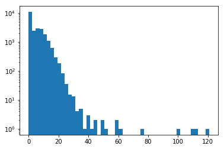

```python
plt.hist(impactPerVenue1List,bins = 50,log=True)
plt.show()
```

# 2 Association Rules

```python
import sys
pathOfData = input("Enter data file path:")
variables_list = []

file = open("kosarak.arff", "w")

file.write("@RELATION kosarak\n")
for i in range(0,41270):
    file.write("@ATTRIBUTE j" + str(i) + " {0, 1}\n" )
file.write("@DATA\n")

with open(pathOfData) as f:
    line = f.readline()
    while line:
        temp = "{"
        variables_list = line.strip("\n").split()
        variables_list = list(map(int, variables_list))
        variables_list = set(variables_list)
        variables_list = sorted(variables_list)

        for i in variables_list:
            temp += str(int(i-1)) + " 1, "
        temp = temp[:(len(temp)-2)] + "}"

        file.write(temp)
        line = f.readline()

file.close()
```

```
Enter data file path:C:\\Users\\saich\\Desktop\\UnsupervisedML\\kosarak.dat
```

It took about 19 seconds to convert from .dat file to .arff file.

It took nearly 11 seconds to load the file to Weka.

Run 1- 5 Run 2- 4 Run 3- 5 Run 4- 6 Run 5- 6

Average = 5 seconds

Average time is very less when compared to time taken for conversion and upload into weka.

FPGrowth found 2 rules (displaying top 2)

1. [i11=1, i218=1, i148=1]: 50098 ==> [i6=1]: 49866 conf:(1) lift:(1.64) lev:(0.02) conv:(84.4)
2. [i11=1, i148=1]: 55759 ==> [i6=1]: 55230 conf:(0.99) lift:(1.63) lev:(0.02) conv:(41.3)

# Parsing 20NG and MNIST data to perform KNN

Importing necessary libraries

```python
from sklearn.datasets import fetch_20newsgroups
from sklearn.feature_extraction.text import CountVectorizer
from sklearn.feature_extraction.text import TfidfTransformer
from sklearn.feature_extraction.text import TfidfVectorizer
from sklearn.metrics.pairwise import cosine_similarity
from sklearn.metrics.pairwise import euclidean_distances
from sklearn.model_selection import train_test_split
from scipy import sparse
from numpy import linalg as LA
import numpy as np
import pandas as pd
import mnist
import scipy.misc
```

```python
20 Newgroup necessary parsing
```

```python
vectorizer = CountVectorizer()

#acquiring the complete data
completeNgData = fetch_20newsgroups(subset='all')
completeNGParsed = vectorizer.fit_transform(completeNgData.data)

#acquiring the training data
trainNgData = fetch_20newsgroups(subset='train')
trainNGParsed = vectorizer.fit_transform(trainNgData.data)

#acquiring the test data
testNgData = fetch_20newsgroups(subset='test')
testNGParsed = vectorizer.fit_transform(testNgData.data)

#Finding similarity matrices for complete dataset
#Here, distance metrics used are cosine distance and euclidean distance
completeCSDistance = cosine_similarity(completeNGParsed)
completeEuclideanDistance = euclidean_distances(completeNGParsed, completeNGParsed)


#Finding similarity matrices for train dataset
#Here, distance metrics used are cosine distance and euclidean distance
#trainCSDistance = cosine_similarity(trainNGParsed)
#trainEuclideanDistance = euclidean_distances(trainNGParsed, trainNGParsed)

#Finding similarity matrices for test dataset
#Here, distance metrics used are cosine distance and euclidean distance
#testCSDistance = cosine_similarity(testNGParsed)
#testEuclideanDistance = euclidean_distances(testNGParsed, testNGParsed)
```

MNIST data parsing and similarity matrix calculation

```python
#Acquiring the necessary inputs
Train_X = mnist.train_images()
Test_X = mnist.test_images()
Train_Y = mnist.train_labels()
Test_Y = mnist.test_labels()

#Because of the huge size of mnist data, computing similarities for complete data is very tedious.
#By doing stratified sampling we can make sure that the population magnitudes of each group are still conserved in the
#output sample data
sampledTrain_X, sampledTest_X, sampledTrain_Y, sampledTest_Y = train_test_split(
    Test_X, Test_Y, train_size=.2, stratify = Test_Y)

#X data obtained is in 3 dimensions, hence inorder to make computation feasible we change it to 2
finalTrain_X = sampledTrain_X.reshape((sampledTrain_X.shape[0], sampledTrain_X.shape[1] * sampledTrain_X.shape[2]))
#Due to the computational capabilities available the similarity matrix calculation will be done on sampled training
#dataset
trainCosineSimilarityMatrix = cosine_similarity(finalTrain_X)
trainEuclideanMatrix = euclidean_distances(finalTrain_X)

finalTest_X = sampledTest_X.reshape((sampledTest_X.shape[0], sampledTest_X.shape[1] * sampledTest_X.shape[2]))

#The complete data after reshaping can be obtained as follows
TotalData = np.concatenate((finalTrain_X,finalTest_X),axis = 0)
```

```python
finalTrain_X.shape
```

```
(2000, 784)
```

```python
finalTest_X.shape
```

```
(8000, 784)
```

```python
#Similarity matrices for complete dataset can be obtained as follows
totalDataCSDistance = cosine_similarity(TotalData)
totalDataEuclideanDIstance = euclidean_distances(TotalData)
```

K Nearest Neighbors

```python
def KNearestNeighbors(D,idx,k,sim):
    indexOfNeighbors = []
    if (D == "cosine"):
        indexOfNeighbors = list(np.argsort(sim[idx])[-(k+1):])
        indexOfNeighbors.remove(idx)
    elif (D == "euclidean"):
        indexOfNeighbors = list(np.argsort(sim[idx])[:(k+1)])
        indexOfNeighbors.remove(idx)
    predns = {}
    TBD = completeNgData.target
    TBDLabel = completeNgData.target_names
    Acc = 0
    for i in indexOfNeighbors:
        pred = TBDLabel[TBD[i]]
        if(predns.get(pred) == None):
            predns[pred] = 1
        else:
            predns[pred] += 1
    return (max(predns, key=predns.get))
```

The below code snippet helps to understand that the output label of a random index matches with its actual label

```python
neighbors_list = KNearestNeighbors("cosine",12960,6,completeCSDistance)
```

[output not shown]

```python
neighbors_list
```

```
'misc.forsale'
```

```python
completeNgData.target_names[completeNgData.target[12960]]
```

```
'misc.forsale'
```

```python
def CalculateAccuracy():
    Acc = 0
    for i in range(11315,18846):
        PredLabels = KNearestNeighbors("cosine", i, 6, completeCSDistance)
        if (PredLabels == completeNgData.target_names[completeNgData.target[i]]):
            Acc += 1
    return Acc/7531
```

```python
A = CalculateAccuracy()
```

```python
A
```

```
0.5993891913424512
```

Hence, we have obtained an accuracy of 59% for 20 NG data using KNN

# For MNIST Data

```python
TY = np.concatenate((sampledTrain_Y,sampledTest_Y),axis = 0)
```

```python
def KNearestNeighborsMNIST(D,idx,k,sim):
    indexOfNeighbors = []
    if (D == "cosine"):
        indexOfNeighbors = list(np.argsort(sim[idx])[-(k+1):])
        indexOfNeighbors.remove(idx)
    elif (D == "euclidean"):
        indexOfNeighbors = list(np.argsort(sim[idx])[:(k+1)])
        indexOfNeighbors.remove(idx)
    predns = {}
    Acc = 0
    for i in indexOfNeighbors:
        pred = TY[i]
        if(predns.get(pred) == None):
            predns[pred] = 1
        else:
            predns[pred] += 1
    return (max(predns, key=predns.get))
```

```python
TY.shape
```

```
(10000,)
```

```python
TY[4699]
```

```
7
```

```python
def CalculateAccuracy():
    Acc = 0
    for i in range(2001,10000):
        PredLabels = KNearestNeighborsMNIST("cosine", i, 9, totalDataCSDistance)
        if (PredLabels == TY[i]):
            Acc += 1
    return Acc/7999
```

```python
AccMNIST = CalculateAccuracy()
```

```python
AccMNIST
```

```
0.9562445305663207
```

Hence, the accuracy obtained is 95.6% on MNIST dataset using KNN